# Milestone 6: Infectious Disease Outbreak in California

Nilson Palma, Michelle Zhen Huang

2025-12-15

# Introduction

## Scenario 1: Infectious Disease Outbreak (Simulated) in California

The `sim_novelid_CA.csv` file and `sim_novelid_LACounty.csv` file together represent simulated morbidity for the entire state of California. This analysis combines and analyzes these datasets to understand the temporal and demographic patterns of the outbreak.

## Problem Statement

There is a novel infectious respiratory disease outbreak in California. Data was collected from 2023 and included data on cases and case severity by demographic categories (age category, race, sex) and geographic categories (county) for California counties and population data. As part of the California Department of Public Health surveilling the infectious respiratory disease outbreak, we are interested in examining the course of the outbreak, if it is disproportionately affecting certain demographic or geographic populations and how prevention and treatment resources should be allocated.

## Methods

Data for this analysis came from three simulated 2023 datasets. The sim_novelid_CA.csv file contained weekly morbidity data (new infections and severe cases) by county, age group, sex, and race/ethnicity for all California counties except Los Angeles. The sim_novelid_LACounty.csv file provided equivalent morbidity data for Los Angeles County, which operates a separate surveillance system. The ca_pop_2023.csv file provided 2023 population estimates by county and demographic categories, which served as denominators for rate calculations. Data preparation involved standardizing variable names and coding schemes across datasets. Race/ethnicity categories were recoded from numeric values to descriptive labels matching California Department of Finance classifications. Age categories in the population data (0-4, 5-11, 12-17) were collapsed to match the broader categories in the morbidity data (0-17). County names were standardized to enable successful joins. Rows with missing values were excluded to ensure complete records for stratified analyses. Weekly incidence rates per 100,000 population were calculated by dividing new infections by the population denominator and multiplying by 100,000. This standardization enables fair comparisons across demographic groups of different sizes. Attack rates (cumulative proportion infected) and severity rates (proportion of cases with severe outcomes) were calculated for summary statistics. All measures were stratified by age group and race/ethnicity to identify disparities. CDC epidemiological weeks (Sunday start) were used as the temporal unit for time series analysis.

# Data Preparation

## Load and Clean Morbidity Data

First, we loaded the data, and cleaned the names of the columns in the datasets.

## Standardize Column Names and Select Variables

We selected relevant variables to our analysis for each data source.

## Handle Missing Data

We removed rows with missing values to ensure clean joins.

## Dates and CDC Week

We fixed date format for LA County. CDC epidemiological weeks start on Sunday and are the standard for disease surveillance reporting. So we set the week to start on Sunday. We then created the CDC week for CA dataset from time_int variable and for LA County from diagnosis date.

## Recode Race/Ethnicity Categories

We converted the numeric race codes to descriptive labels for CA data, and ensured race is factor type for LA data.

## Combine Datasets

We merged the CA and LA County morbidity data.

# Population Data Preparation

## Clean and Standardize Population Data

We selected and renamed relevant columns to match morbidity data. We then standardized the race/ethnicity labels to match morbidity data. We reclassified the age categories to match morbidity data (e.g., 0-17 instead of 0-4, 5-11, 12-17).

## Standardize County Names

To standardize the county names, we removed the “County” suffix from morbidity data to match population data. We also made sure there was consistent formatting in population data.

## Join Morbidity and Population Data

We used a left join to add population data to morbidity data.

# Time Series Analysis

## Calculate Weekly Rates

We created a dataset with weekly cumulative incidence rates and dropped columns not relevant to our time series analysis.

## Overall California Outbreak Trajectory

We aggregated to state level by week to determine the overall California outbreak trajectory.

## Stratify by Age Group

We aggregated by age group and week to stratify by age group.

## Stratify by Race/Ethnicity

We aggregated by race/ethnicity and week to stratify by race/ethnicity.

# Results

## Epidemic Curve by Age Group

The outbreak affected all age groups, with clear differences in disease burden by age.

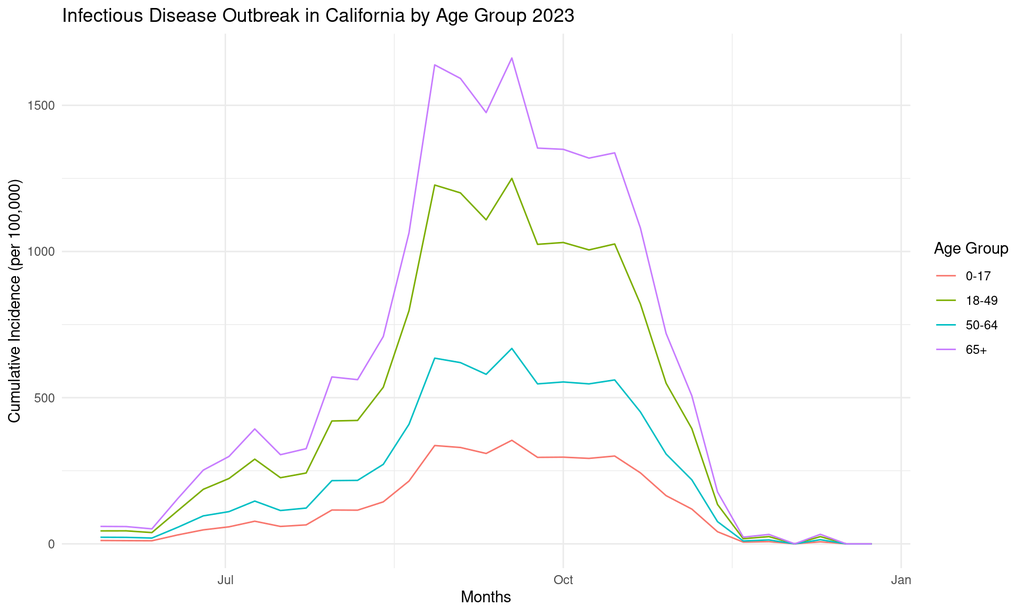

**Key Findings:**

- All age groups peaked simultaneously around August-September 2023.
- Incidence increases with age, however, cumulative incidence for 18-49 > 50-64.
- Persons aged 65+ experienced the highest burden (~1,600 per 100,000 at peak).
- Persons aged 0-17 had the lowest incidence (~350 per 100,000 at peak).

## Epidemic Curve by Race/Ethnicity

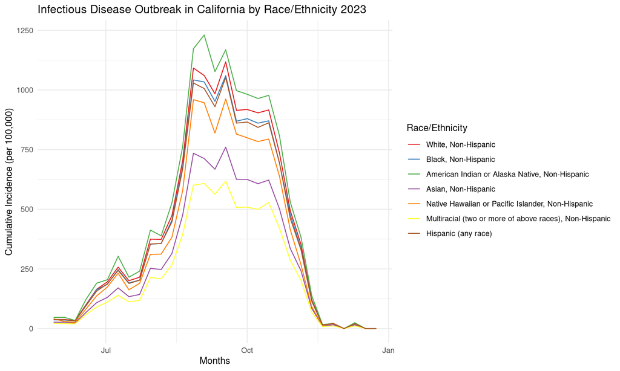

**Key Findings:**

- American Indian or Alaska Native (Non-Hispanic) populations experienced the highest peak incidence (~1,250 per 100,000).
- All racial/ethnic groups followed similar temporal patterns, peaking around the same time.

# Summary Statistics

## Summary by Age Group

Outbreak Summary Statistics by Age Group

| Age Group | Total Cases | Average Population | Peak Weekly Cumulative Incidence (per 100k) | Total Severe Cases | Attack Rate (%) | Severe Rate (%) |
| --- | --- | --- | --- | --- | --- | --- |
| 0-17 | 353210 | 8694111 | 354.22 | 363 | 4.06 | 0.10 |
| 18-49 | 2467284 | 17106505 | 1250.22 | 29325 | 14.42 | 1.19 |
| 50-64 | 540481 | 7086797 | 668.40 | 2822 | 7.63 | 0.52 |
| 65+ | 1188608 | 6221657 | 1662.00 | 94416 | 19.10 | 7.94 |

**Key Findings:**

- Overall, Cumulative Incidence (per 100k), Attack Rate, and Severe Rate generally increased with age, with the exception that the 18–49 age group had higher rates than the 50–64 group.
- Persons aged 65+ experienced the highest burden across all 3 measures: Cumulative Incidence (per 100k), Attack Rate, and Severe Rate .
- Persons aged 0-17 had the lowest burden across all 3 measures: Cumulative Incidence (per 100k), Attack Rate, and Severe Rate.

## Summary by Race/Ethnicity

Outbreak Summary Statistics by Race/Ethnicity

| Race/Ethnicity | Total Cases | Average Population | Peak Weekly Cumulative Incidence (per 100k) | Total Severe Cases | Attack Rate (%) | Severe Rate (%) |
| --- | --- | --- | --- | --- | --- | --- |
| American Indian or Alaska Native, Non-Hispanic | 22195 | 158672 | 1230.21 | 671 | 13.99 | 3.02 |
| White, Non-Hispanic | 1778774 | 13848282 | 1117.81 | 63448 | 12.84 | 3.57 |
| Black, Non-Hispanic | 271836 | 2211518 | 1060.00 | 7118 | 12.29 | 2.62 |
| Hispanic (any race) | 1796696 | 14829946 | 1052.14 | 36484 | 12.12 | 2.03 |
| Native Hawaiian or Pacific Islander, Non-Hispanic | 16921 | 153729 | 962.08 | 410 | 11.01 | 2.42 |
| Asian, Non-Hispanic | 546770 | 6295420 | 760.47 | 16568 | 8.69 | 3.03 |
| Multiracial (two or more of above races), Non-Hispanic | 116391 | 1611503 | 617.87 | 2227 | 7.22 | 1.91 |

**Key Findings:**

- American Indian or Alaska Native (Non-Hispanic) populations experienced the highest attack rate (14.0%), nearly double that of the lowest group (Multiracial, 7.2%).
- Asian (Non-Hispanic) populations showed low incidence (8.7% attack rate) but high case severity (3.03%), a pattern potentially explained by an older age distribution in this population.

# Discussion